# ggplot2 by Hadley Wickham (book example)

# Themes

There are two themes in ggplot. One is the default grey background with white gridlines while the other one is white background with grey gridlines.

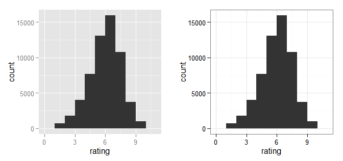

```r
grid.arrange(
  ggplot(movies, aes(x=rating)) + geom_histogram(binwidth=1),
  ggplot(movies, aes(x=rating)) + geom_histogram(binwidth=1) + theme_bw(),
  ncol=2
)
```

### Adjustment for text

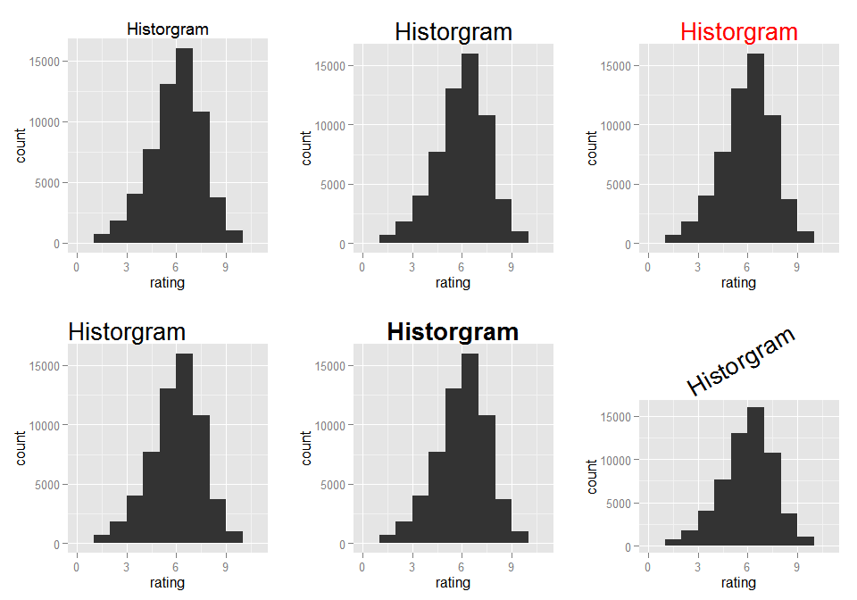

```r
myhist <- ggplot(movies, aes(x=rating)) + geom_histogram(binwidth=1) + labs(title="Historgram")

grid.arrange(
  myhist,
  myhist + theme(plot.title=element_text(size=20)),
  myhist + theme(plot.title=element_text(size=20, color="red")),
  myhist + theme(plot.title=element_text(size=20, hjust=0)),
  myhist + theme(plot.title=element_text(size=20, face="bold")),
  myhist + theme(plot.title=element_text(size=20, angle=30)),
  ncol=3
)
```

### Adjustment for gridlines and axis

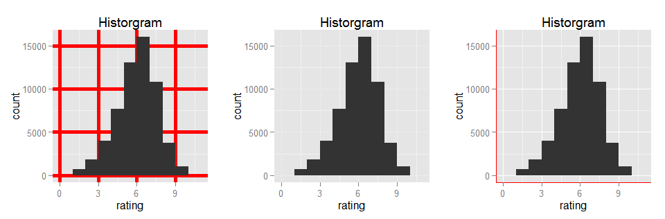

```r
grid.arrange(
  myhist + theme(panel.grid.major=element_line(color="red", size=2)),
  myhist + theme(panel.grid.major=element_line(linetype="dotted")),
  myhist + theme(axis.line=element_line(color="red")),
  ncol=3
)
```

### Adjustment for rectangles and panel background

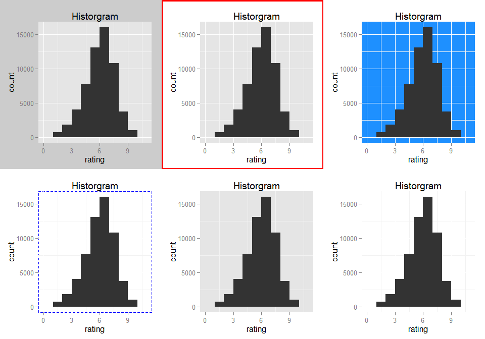

```r
grid.arrange(
  myhist + theme(plot.background=element_rect(fill="grey80", color=NA)),
  myhist + theme(plot.background=element_rect(size=2, color="red")),
  myhist + theme(panel.background=element_rect(fill="dodgerblue")),
  myhist + theme(panel.background=element_rect(fill=NA, color="blue", linetype="dashed")),
  #Use element_blank to remove the theme you don't want
  myhist + theme(panel.grid.major=element_blank()),
  myhist + theme(panel.background=element_blank()),
  ncol=3
)
```

### Set up default theme

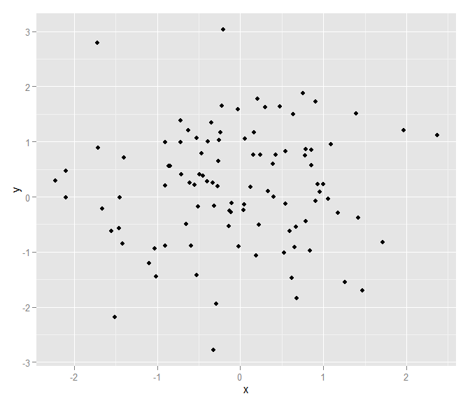

```r
mydata <- data.frame(x=rnorm(100), y=rnorm(100))
ggplot(mydata, aes(x=x, y=y)) + geom_point()
```

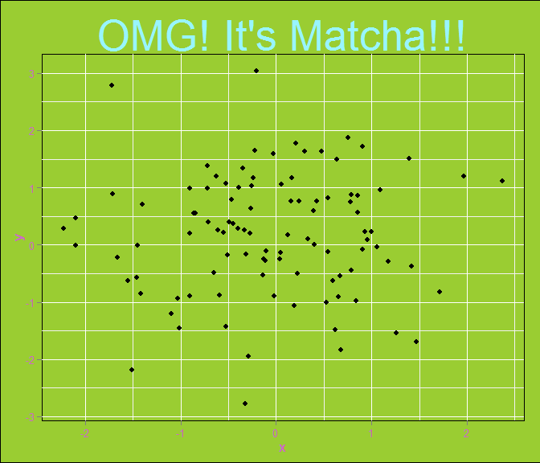

```r
matcha_theme <- theme_set(theme_bw())
theme_set(matcha_theme)
matcha_theme <- theme_update(
  plot.title=element_text(size=40, color="cadetblue1"),
  plot.background=element_rect(fill="olivedrab3"),
  panel.background=element_rect(fill="olivedrab3"),
  axis.text.x=element_text(colour="orchid3"),
  axis.text.y=element_text(colour="orchid3", hjust=1),
  axis.title.x=element_text(colour="orchid3", face="bold"),
  axis.title.y=element_text(colour="orchid3", face="bold", angle=90)
)
ggplot(mydata, aes(x=x, y=y)) + geom_point() + labs(title="OMG! It's Matcha!!!")
```

```r
#Get back to original theme
theme_set(theme_grey())
```

### Save your graph

Use `ggsave()` to save the graph. There are three arguments that you can adjust, height, width, and scale. An alternative way is use the default function in R such as `png()` and `pdf()` and after finishing the plot, use `dev.off()` to close it.

```r
ggplot(mydata, aes(x=x, y=y)) + geom_point()
ggsave(file="matcha.pdf")
```

### Multiple plot on same page

As you may notice, I have used the technique throughout this demo. Now we will focus on the subplot. Here is the example for subplot.

```r
a <- ggplot(economics, aes(x=date, y=unemploy)) + geom_line()
b <- ggplot(economics, aes(x=uempmed, y=unemploy)) + geom_point() + geom_smooth(se=FALSE)
c <- ggplot(economics, aes(x=uempmed, y=unemploy)) + geom_path()
```

```r
csmall <- c + theme_gray(9) + labs(x = NULL, y = NULL) + theme(plot.margin = unit(rep(0, 4), "lines"))
subvp <- viewport(width = 0.4, height = 0.4, x = 0.75, y = 0.35)

b
```

```
geom_smooth: method="auto" and size of largest group is <1000, so using loess. Use 'method = x' to change the smoothing method.
```

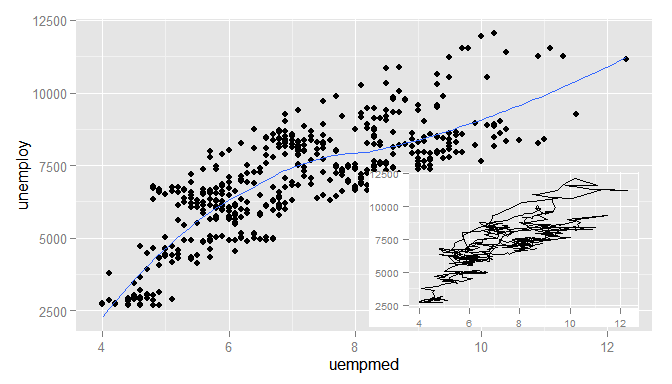

```r
print(csmall, vp = subvp)
```

```r
#Another way to do multiple plot
pushViewport(viewport(layout = grid.layout(2, 2)))
vplayout <- function(x, y){
  viewport(layout.pos.row = x, layout.pos.col = y)
}

print(a, vp = vplayout(1, 1:2))
print(b, vp = vplayout(2, 1))
```

```
geom_smooth: method="auto" and size of largest group is <1000, so using loess. Use 'method = x' to change the smoothing method.
```

[figure not shown]

```r
print(c, vp = vplayout(2, 2))
```

```
geom_smooth: method="auto" and size of largest group is <1000, so using loess. Use 'method = x' to change the smoothing method.
```

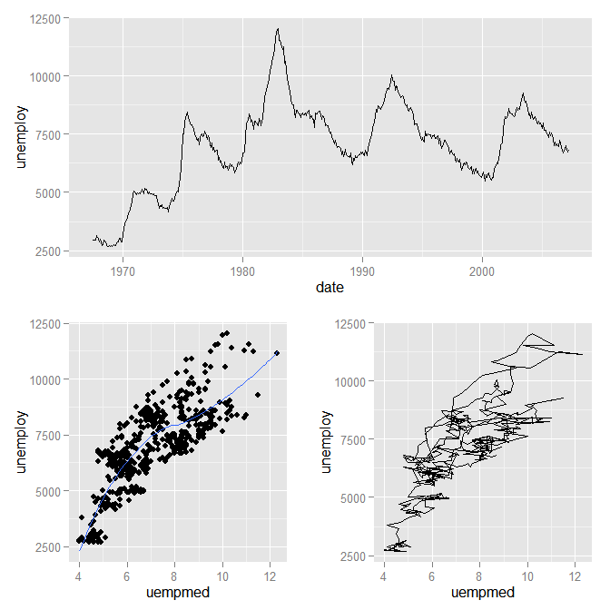

```r
#The same code as previous
grid.arrange(a, arrangeGrob(b, c, ncol=2), nrow=2)
```